# National Youth Commission

Budget evolution and agency-level utilization, FY 2018–2026

August 2026

← All agencies

# Overview

This document profiles the budget of the **National Youth Commission (NYC)** — the government’s sole policy-making, coordinating, and monitoring body for Filipino youth, created under the Youth in Nation-Building Act (RA 8044) — across nine fiscal years, FY 2018 to FY 2026. NYC is one of the **smallest agencies in the national budget**, and it carries the same data constraint as several other commissions: usable program-level execution records were not available, so this review pairs the **proposed-to-enacted budget at the program level** with **budget utilization measured at the agency aggregate**.

Because the program-by-program execution chain cannot be traced, the emphasis is on what NYC’s budget is *composed of*, how Congress adjusts it, and — at the whole-agency level — how much of what is released actually gets obligated and paid out.

Two features define NYC’s budget. First, it is **small and highly volatile**: the enacted budget mostly sits between ₱120M and ₱315M, but in FY 2025 it **nearly tripled to ₱632M** before reverting. Second, it is **almost one program** — youth-development policy and coordination is about 92% of the budget, so the agency is unusually easy to read.

Set against the population it serves, NYC is tiny. With **31.4 million Filipinos aged 15–30** (2020 census, the RA 8044 definition of youth), the 2026 budget works out to about **₱10 per young person per year**. So the questions this review raises are less about whether the agency spends what it receives than about **whether the envelope is adequate to a national mandate — and, when a windfall does arrive, whether NYC can absorb it**.

# 1 Executive summary

**NYC is among the smallest agencies in the national budget.** The government’s sole policy-making and coordinating body for Filipino youth, its enacted budget has mostly sat between **₱120M and ₱315M**, reaching ₱315M in 2026.

**Against the country’s youth, that is tiny.** With **31.4 million Filipinos aged 15–30** (2020 census), the 2026 budget is about **₱10 per young person per year**.

**FY 2025 was extraordinary.** Congress enacted **₱632M against a ₱242M proposal** — a **+₱391M (+162%)** jump that nearly tripled the agency for one year, then reverted to ₱315M in 2026.

**The surge outran the agency’s capacity to spend.** In 2025 NYC obligated only **69%** of its allotment and disbursed just **58%** — its weakest execution on record.

**Almost everything is one program.** Youth-development policy and coordination is about **92% of the 2026 budget**, and the agency is **MOOE-heavy** (program spending) rather than personnel-heavy.

**One organizational move.** NYC shifted from the Office of the President’s cluster to the **DILG** around 2018–2020, and has otherwise kept a stable two-program structure.

> NYC is a very small, one-program agency that Congress only ever adds to. The FY 2025 windfall showed both the upside and the limit: the money arrived, but well under two-thirds of it went out the door. The open questions are **adequacy and absorptive capacity**.

# 2 A note on the data

**Period.** FY 2018 through FY 2026 for the proposed (NEP) and enacted (GAA) budget, at the P/A/P level. Agency-level execution (Allotments, Obligations, Disbursements) covers FY 2011–2025.

**No program-level execution.** Usable **FAR No. 1** (SAAODB) records were not available for NYC, so there is **no P/A/P-level absorption analysis**. Utilization is shown only at the **agency aggregate** — the gap this review would most like to close with better data.

**Two bases, not directly comparable.** The NEP/GAA figures are **current-year new appropriations only**. The execution figures are DBM’s **published agency aggregates, which combine all available funds** — new, automatic, and continuing appropriations. The two series should not be read one-to-one.

**One reorganization, a stable structure.** NYC’s mother agency moved from the **Other Executive Offices to the DILG** around 2018–2020; its two-program structure is otherwise stable, so program lines are comparable across years. (Because the move straddles departmental wrappers in the source workbook, the agency is aggregated here into one continuous series; no year is double-counted.)

**Population figures.** Per-person comparisons use the **2020 Census of Population and Housing**, which counted **31.40 million Filipinos aged 15–30** — the definition of “youth” under RA 8044.

**Expense classes.** Personnel Services (PS), Maintenance & Other Operating Expenses (MOOE), Capital Outlays (CO). NYC carries no Financial Expenses. **Units are PHP millions** throughout.

# 3 One move to DILG, one core program

NYC moved mother agency once and otherwise kept a simple two-program structure, so its trend lines read cleanly.

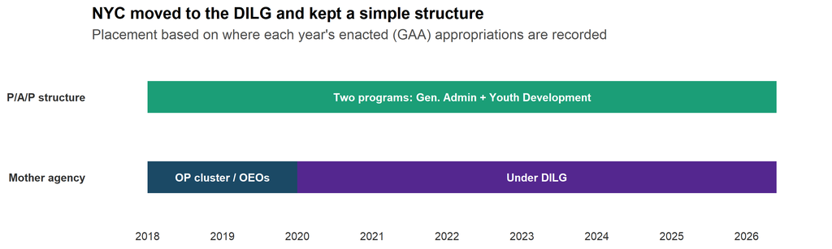

```r
tl <- tibble::tribble(
  ~track,            ~label,                          ~start, ~end,   ~fill,
  "Mother agency",   "OP cluster / OEOs",              2018,   2020,   "#1B4965",
  "Mother agency",   "Under DILG",                     2020,   2026.4, "#54278F",
  "P/A/P structure", "Two programs: Gen. Admin + Youth Development",  2018,   2026.4, "#1B9E77")
ggplot(tl, aes(y = track)) +
  geom_segment(aes(x = start, xend = end, yend = track, color = fill), linewidth = 13, lineend = "butt") +
  scale_color_identity() +
  geom_text(aes(x = (start + end) / 2, label = label), color = "white", fontface = "bold", size = 3.4) +
  scale_x_continuous(breaks = 2018:2026, limits = c(2017.7, 2026.6)) +
  labs(title = "NYC moved to the DILG and kept a simple structure",
       subtitle = "Placement based on where each year's enacted (GAA) appropriations are recorded", x = NULL, y = NULL) +
  theme_nyc() + theme(panel.grid.major.y = element_blank(),
        axis.text.y = element_text(face = "bold", color = "grey20"))
```

With one operating program throughout, almost all of NYC’s budget flows through youth-development policy and coordination — which makes the composition and the FY 2025 anomaly easy to trace.